# Midterm Exam Part 2: Hands-on Coding Assignment (12 points; 14 questions)

## Instructions

Type in your SUID in place of the zeros below and run the cell (click Ctrl + Enter):

```r
suid <- 326926205
```

The block of code below creates a custom data set for you to analyze. Your dataset is different from every other student’s dataset. The goal of this part of the exam is to write code and comments that address the research questions described below. The quality of your comments is critical to your success on this exam! You will only be submitting this file and there are several important results that require an explanation in plain language. Pay close attention to the research questions described below when writing your code and comments.

**Do not modify any of the code, just run it as is:**

```r
if (suid == 0) {cat("Please update your SUID (above) before running this code.")} else {cat(paste("Lyft/Uber Fare Comparison Study Number:",suid,"\n")); set.seed(suid); grp1id <- paste("Lyft",substr(as.hexmode(suid),1,2),sep="_"); grp2id <- paste("Uber",substr(as.hexmode(suid),1,2),sep="_"); ssize <- floor(runif(n=1,min=100,max=140)); driver <- 1:ssize; base <-round(rnorm(n=ssize,mean=25,sd=5), digits=2);lyft <- round(rowMeans(cbind(base, runif(ssize,min=15,max=35))),digits=2);if ((suid %% 2)==1) {uber <- round(rowMeans(cbind(base, runif(ssize,min=10,max=40))),digits=2) } else { uber <- round(rowMeans(cbind( base + rexp(n=ssize,rate=0.25), rnorm(n=ssize,mean=25,sd=5))),digits=2)}; testDF <- data.frame(driver,lyft,uber);cat(paste("Sample size for this study:",ssize)); t1 <- testDF[,3] + 0.25*rnorm(n=ssize, (mean(testDF[,3])),sd=5);t <-testDF[,2] + 1.1*rnorm(n=ssize,mean(testDF[,2]),sd=20); t[ t < 0] <- 0;t1[ t1 < 0] <- 0;testDF <- data.frame(driver,lyft,uber, t, t1);if ((suid %% 2)==1) {states <- c("New York", "Texas", "Texas", "Florida")}else {states <- c("California", "California","Texas", "Georgia") }; testDF$tmp1 <- sample(states, nrow(testDF), replace=TRUE); testDF$tmp2 <- testDF$tmp1;rm(states);names(testDF)[2]<-grp1id; names(testDF)[3]<-grp2id;names(testDF)[5]<-paste0(grp2id, "_distance");names(testDF)[4]<-paste0(grp1id, "_distance");names(testDF)[7]<-paste0(grp2id, "_state");names(testDF)[6]<-paste0(grp1id, "_state"); rm(base); rm(lyft); rm(uber); rm(ssize); rm(grp1id); rm(grp2id); rm(driver); rm(t); rm(t1)}
```

```
## Lyft/Uber Fare Comparison Study Number: 326926205
## Sample size for this study: 117
```

## Your Assignment: rYdZ Analysis

The code you just ran generates a unique dataframe called **testDF**.

You can explore it by running, e.g. head(testDF).

There is an upstart in the ride-sharing market: The new start-up firm **rYdZ** (pronounced rides) is driver-owned and operated. In addition to providing safe rides at competitive prices, the?mission of **rYdZ** is to provide a working wage to **rYdZ** drivers. But the leadership team at **rYdZ** believes there is a problem: the two giants in the industry, **Lyft** and **Uber**, are coordinating to set prices for rides that are artificially low? The team at **rYdZ** has produced a data set of more than 100 fares offered to drivers from **Lyft** and **Uber**. Your job is to analyze this data set and infer whether there is some sort of coordination between **Lyft** and **Uber** to set prices, as well as understand if either is pricing based on miles driven, or perhaps, based on geography.

## Data Set Description:

Your data set contains **five variables**: The **ride number**, the **fare** (in dollars and cents) of a ride offered to a driver from Lyft, and the **distance** of that ride (in miles). There is also a **fare for a different ride** offered to a driver through Uber (and the **distance of that trip**). There are at least 100 observations (rows) in your dataset, and possibly more. Each observation was done at roughly the same time for Uber and Lyft (the data for the ride in a row was collected at roughly the same time).

## Research Questions (tasks to do):

1. Output the 5th Lift fare (0.5 pts)

```r
library(tidyverse)
testDF %>% slice(5) %>% select(Lyft_13)
```

```
##   Lyft_13
## 1   26.04
```

2. Describe the fares provided by Lyft and Uber (separately) using descriptive statistics that you calculate in R (1 pts):

```r
summary(testDF$Lyft_13)
```

```
##    Min. 1st Qu.  Median    Mean 3rd Qu.    Max.
##   15.57   21.67   24.37   24.36   26.93   32.61
```

```r
summary(testDF$Uber_13)
```

```
##    Min. 1st Qu.  Median    Mean 3rd Qu.    Max.
##   12.58   20.72   24.13   24.44   28.01   35.75
```

3. Describe the shape of the distribution for Lyft fares. Do the same for Uber fares (1 pt)

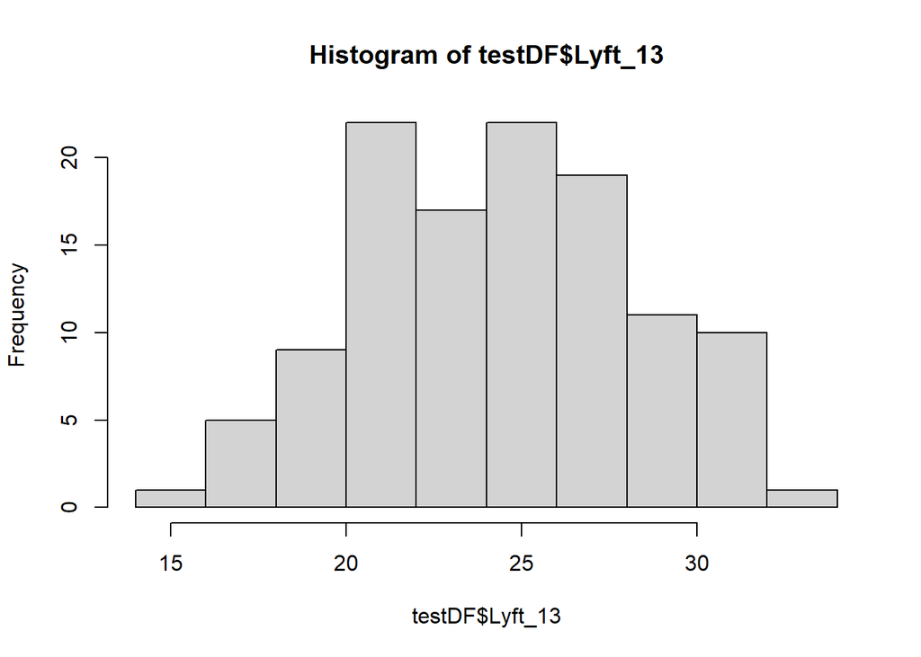

```r
# fares are normally distributed. histogram plot looks close to bell shaped curve. it is also evident from
# the statistics above : mean and median of fares are almost equal
hist(testDF$Lyft_13)
```

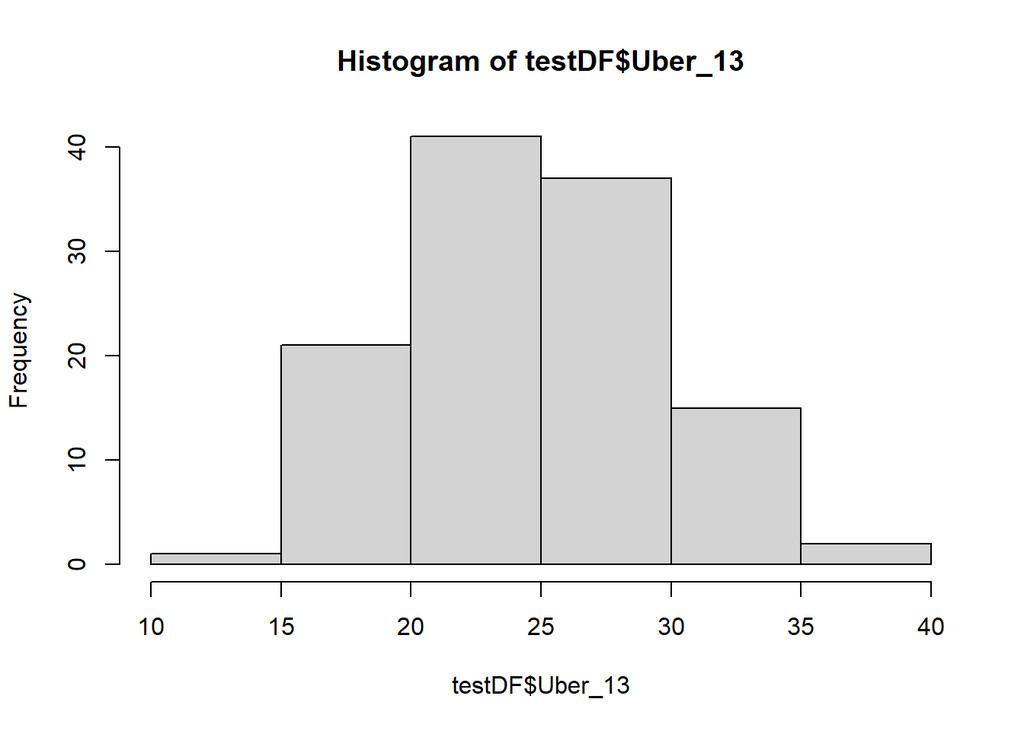

```r
# fares are normally distributed. histogram plot looks close to bell shaped curve. it is also evident from
# the statistics above : mean and median of fares are almost equal
hist(testDF$Uber_13)
```

4. Based on the fares offered by both companies, on average, which company is more expensive, Lyft or Uber? By how much? (0.5 pts)

```r
testDF$Lyft_13 %>% mean()
```

```
## [1] 24.36214
```

```r
testDF$Uber_13 %>% mean()
```

```
## [1] 24.44436
```

```r
mean(testDF$Lyft_13) - mean(testDF$Uber_13)
```

```
## [1] -0.08222222
```

```r
# Uber is little expensive by approx 0.08$
```

5. Create a new attribute, called ‘diff’ in testDF, that represents the difference in fares between Uber and Lyft for each observation - in other words, the difference for each row(0.5 pts):

```r
testDF <- testDF %>% mutate(diff=Uber_13-Lyft_13)
```

6. Describe the shape of the distribution for this new variable(0.5 pts)

```r
summary(testDF$diff)
```

```
##     Min.  1st Qu.   Median     Mean  3rd Qu.     Max.
## -9.97000 -3.25000  0.11000  0.08222  3.09000 12.11000
```

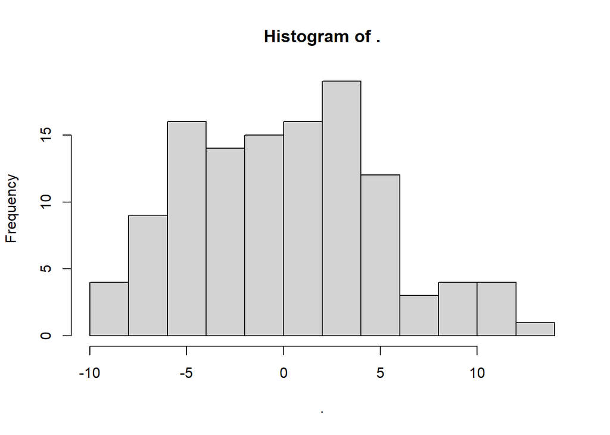

```r
testDF$diff %>% hist()
```